# DeCoVart-use-cases

Bastien Chassagnol[^1]

Gregory Nuel[^2]

Etienne Becht[^3]

# Model

```r
html_ouput <- knitr::is_html_output() # store which type is asked as an output
library(DeCovarT)
library(ggplot2)
library(dplyr)
library(pkgdown) # generate automated links to R packages and functions
library(kableExtra)
library(flextable)

# define function to automaticaly colour some sections, with respect to the output of the document
colorize <- function(x, color) {
  if (knitr::is_latex_output()) {
    sprintf("\\textcolor{%s}{%s}", color, x)
  } else {
    sprintf("<span style='color: %s;'>%s</span>", color, x)
  }
}
```

We introduce the following notations:

- $(\boldsymbol{y}=(y_{gi}) \in \mathbb{R}_+^{G\times N}$ is the global bulk transcriptomic expression, measured in $N$ individuals.
- $\boldsymbol{X}=(x_{gj}) \in \mathcal{M}_{\RR^{G\times J}}$ the signature matrix of the mean expression of $G$ genes in $J$ purified cell populations.
- $\boldsymbol{p}=(p_{ji})\in ]0, 1[^{J \times N}$ the unknown relative proportions of cell populations in $N$ samples

As in most traditional deconvolution models, we assume that the total bulk expression can be reconstructed by summing the individual contributions of each cell population weighted by its frequency, as stated explicitly in the following linear matricial relationship (Eq.(1)):

$$\begin{equation}
\boldsymbol{y}=\boldsymbol{X} \times \boldsymbol{p}
\tag{1}
\end{equation}$$

In addition, we consider the following unit simplex constraint on the cellular ratios (Eq.(2)):

$$\begin{equation}
\begin{cases}
\sum_{j=1}^J p_{j}=1\\
\forall j \in \widetilde{J} \quad p_j\ge 0
\end{cases}
\tag{2}
\end{equation}$$

## Rationale of the new generative model

However, in real conditions with technical and environmental variability, the strict linearity of the deconvolution does not strictly hold. Thus, an additional error term is usually added, assumed to follow a *homoscedastic* zero-centred Gaussian distribution and with pairwise independent response measures while the exogenous variables (here, the purified expression profiles) are supposed determined: this set of conditions is referred to as the Gaussian-Markow assumptions. In that configuration, the MLE (maximum likelihood estimate) that bast describes this standard linear model is equal to the ordinary least squares (OLS) estimate.

In contrast to this canonical approach, in DeCovarT, we relax the *exogeneity* property by treating exogenous variables $\boldsymbol{X}$ as random variables rather than determined measures, in a process close to the approach of the DSection algorithm [1]. However, to our knowledge, we are the first to weaken the independence assumption between observations by explicitly incorporating the intrinsic covariance structure of the transcriptome of each purified cell population. To do so, we conjecture that the $G$-dimensional vector $\boldsymbol{x}_j$ characterising the transcriptomic expression of each cell population follows a multivariate Gaussian distribution: $\boldsymbol{x}_j \sim \mathcal{N}_G(\boldsymbol{\mu}_{.j}, \boldsymbol{\Sigma}_{j})$, with $\boldsymbol{\mu}_{.j}$ the mean purified transcriptomic expression and $\boldsymbol{\Sigma}_{j}$ the covariance matrix, that we constrain to be positive-definite and of full rank and that is inferred using the output of the gLasso algorithm [2]. We display respectively the graphical models associated to the standard linear deconvolution model and our new innovative generative model used by the DeCovarT algorithm in subfigures a) and b), in Fig.1.

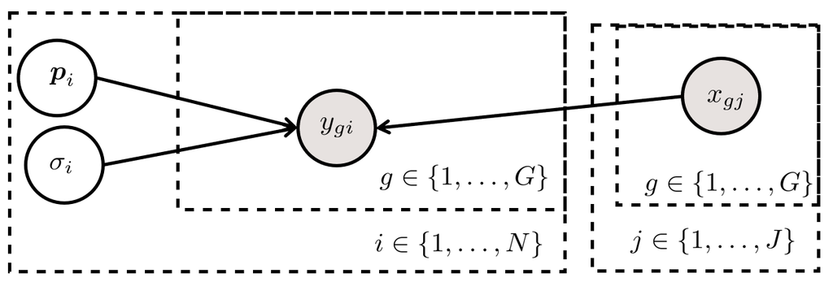

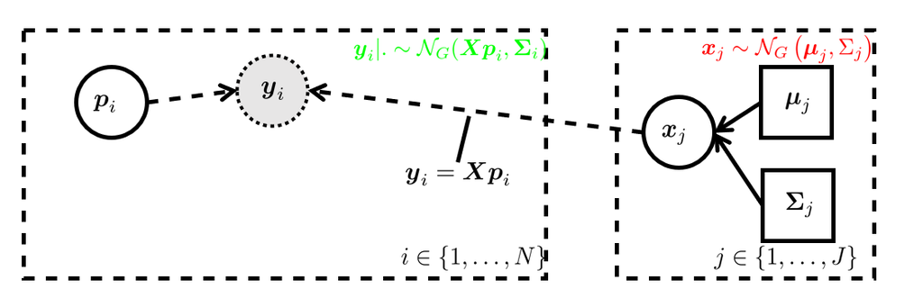

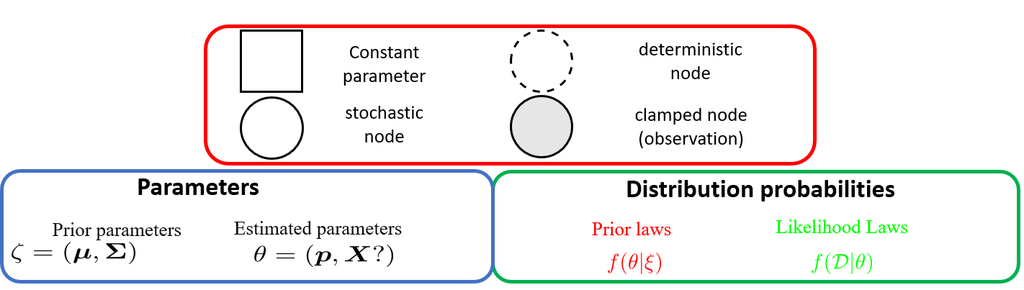

Figure 1: We use the standard graphical convention of graphical models, as depicted in [RevBayes](https://revbayes.github.io/tutorials/intro/graph_models.html) webpage. For identifiability reasons, we conjecture that all variability arises from the stochastic nature of the covariates.

## Derivation of the log-likelihood

First, we *plugged-in* the mean and covariance parameters $\zeta_j=\left(\boldsymbol{\mu}_{.j}, \boldsymbol{\Sigma}_j\right)$ inferred in the previous step. Then, by letting $\boldsymbol{\zeta}=(\boldsymbol{\mu}, \boldsymbol{\Sigma}), \quad \boldsymbol{\mu}=(\boldsymbol{\mu}_{.j})_{j \in \widetilde{J}} \in \mathcal{M}_{G \times J}, \quad \boldsymbol{\Sigma} \in \mathcal{M}_{G \times G}$ the known parameters and $\boldsymbol{p}$ the unknown cellular ratios, the conditional distribution $\boldsymbol{y}|(\boldsymbol{\zeta}, \boldsymbol{p})$ is the convolution of pairwise independent multivariate Gaussian distributions, which is also a multivariate Gaussian distribution (Eq.(3)), deduced from the *affine invariant* property of Gaussian distributions.

$$\begin{equation}
\boldsymbol{y}|(\boldsymbol{\zeta}, \boldsymbol{p}) \sim \mathcal{N}_G(\boldsymbol{\mu} \boldsymbol{p}, \boldsymbol{\Sigma}) \text{ with } \boldsymbol{\mu} = (\boldsymbol{\mu}_{.j})_{j \in \widetilde{J}}, \quad \boldsymbol {p}=(p_1, \ldots, p_J) \text{ and } \boldsymbol{\Sigma}=\sum_{j=1}^J p_{j}^2\boldsymbol{\Sigma}_{j}
\tag{3}
\end{equation}$$

From Eq.(3), we readily compute the associated conditional log-likelihood (Eq.(4)):

$$\begin{equation}
\ell_{\boldsymbol{y} | \boldsymbol{\zeta}}(\boldsymbol{p})=C + \log\left(\DET \left(\sum_{j=1}^J p_{j}^2\boldsymbol{\Sigma}_{j}\right)^{-1}\right) - \frac{1}{2} (\boldsymbol{y} - \boldsymbol{p} \boldsymbol{\mu})^\top \left(\sum_{j=1}^J p_{j}^2\boldsymbol{\Sigma}_{j}\right)^{-1} (\boldsymbol{y} - \boldsymbol{p}\boldsymbol{\mu})
\tag{4}
\end{equation}$$

## First and second-order derivation of the unconstrained DeCovarT log-likelihood function

The stationary points of a function and notably maxima, are given by the roots (the values at which the function crosses the $x$-axis) of its gradient, in our context, the vector: $\nabla \ell: \RR^J \to \RR^J$ evaluated at point $\nabla \ell (\boldsymbol{p}): ]0, 1[^J \to \RR^J$. Since the computation is the same for any cell ratio $p_j$, we give an explicit formula for only one of them (Eq.(5)):

$$\begin{equation}
\begin{split}
\frac{\partial \ell_{\boldsymbol{y} | \boldsymbol{\zeta}}(\boldsymbol{p})}{\partial p_j} =& \scriptstyle \frac{\partial \log\left(\DET(\boldsymbol{\Theta})\right)}{\partial p_j} -\frac{1}{2} \left[\frac{\partial (\boldsymbol{y} - \boldsymbol{\mu} \boldsymbol{p})^\top}{\partial p_j}\boldsymbol{\Theta}(\boldsymbol{y} - \boldsymbol{\mu} \boldsymbol{p}) + (\boldsymbol{y} - \boldsymbol{\mu} \boldsymbol{p})^\top\frac{\partial\boldsymbol{\Theta}}{\partial p_j}(\boldsymbol{y} - \boldsymbol{\mu} \boldsymbol{p}) + (\boldsymbol{y} - \boldsymbol{\mu} \boldsymbol{p})^\top\boldsymbol{\Theta} \frac{\partial (\boldsymbol{y} - \boldsymbol{\mu} \boldsymbol{p})}{\partial p_j} \right]\\
=& \scriptstyle -\Tr \left(\boldsymbol{\Theta} \frac{\partial \boldsymbol{\Sigma}}{\partial p_j} \right) - \frac{1}{2} \left[ - \boldsymbol{\mu}_{.j}^\top\boldsymbol{\Theta}(\boldsymbol{y} - \boldsymbol{\mu} \boldsymbol{p}) - (\boldsymbol{y} - \boldsymbol{\mu} \boldsymbol{p})^\top\Theta\frac{\partial \Sigma}{\partial p_j}\Theta(\boldsymbol{y} - \boldsymbol{\mu} \boldsymbol{p}) - (\boldsymbol{y} - \boldsymbol{\mu} \boldsymbol{p})^\top\boldsymbol{\Theta} \boldsymbol{\mu}_{.j} \right] \\
=& -2p_j \Tr \left(\boldsymbol{\Theta}\boldsymbol{\Sigma}_j\right) +
(\boldsymbol{y} - \boldsymbol{\mu} \boldsymbol{p})^\top\boldsymbol{\Theta} \boldsymbol{\mu}_{.j} \, +
p_j (\boldsymbol{y} - \boldsymbol{\mu} \boldsymbol{p})^\top\boldsymbol{\Theta} \Sigma_j \boldsymbol{\Theta} (\boldsymbol{y} - \boldsymbol{\mu} \boldsymbol{p})
\end{split}
\tag{5}
\end{equation}$$

$$\begin{equation}
\begin{aligned}
\mathbf{H}_{i,i}& =
\frac{\partial^2 \ell}{\partial^2 p_i} =
-2\Tr \left(\boldsymbol{\Theta}\boldsymbol{\Sigma}_i\right) + 4p_i^2 \Tr \left(\left(\boldsymbol{\Theta}\boldsymbol{\Sigma}_i\right)^2\right)
-2p_i(\boldsymbol{y} - \boldsymbol{\mu} \boldsymbol{p})^\top\boldsymbol{\Theta} \boldsymbol{\Sigma}_i \boldsymbol{\Theta} \boldsymbol{\mu_{.i}}\, - \boldsymbol{\mu}_{.i}^\top\boldsymbol{\Theta} \boldsymbol{\mu_{.i}} \, - \\
& 2p_i (\boldsymbol{y} - \boldsymbol{\mu} \boldsymbol{p})^\top \boldsymbol{\Theta}\boldsymbol{\Sigma}_i\boldsymbol{\Theta}\boldsymbol{\mu}_{.i \, -
(\boldsymbol{y} - \boldsymbol{\mu} \boldsymbol{p})^\top\boldsymbol{\Theta} \left(4p_i^2 \boldsymbol{\Sigma}_i \boldsymbol{\Theta} \boldsymbol{\Sigma}_i - \boldsymbol{\Sigma}_i \right)\boldsymbol{\Theta} (\boldsymbol{y} - \boldsymbol{\mu} \boldsymbol{p})}, \quad i \in \widetilde{J} \\
\mathbf{H}_{i,j} &=
\frac{\partial^2 \ell}{\partial p_i \partial p_j} =
4p_j p_i \Tr \left(\boldsymbol{\Theta}\boldsymbol{\Sigma}_j \boldsymbol{\Theta}\boldsymbol{\Sigma}_i \right)
-2p_i(\boldsymbol{y} - \boldsymbol{\mu} \boldsymbol{p})^\top\boldsymbol{\Theta} \boldsymbol{\Sigma}_i \boldsymbol{\Theta} \boldsymbol{\mu_{.j}} - \boldsymbol{\mu}_{.i}^\top\boldsymbol{\Theta} \boldsymbol{\mu_{.j}} \, - \\
& 2p_j (\boldsymbol{y} - \boldsymbol{\mu} \boldsymbol{p})^\top \boldsymbol{\Theta}\boldsymbol{\Sigma}_j\boldsymbol{\Theta} \boldsymbol{\mu}_{.i\, -
4p_ip_j(\boldsymbol{y} - \boldsymbol{\mu} \boldsymbol{p})^\top\boldsymbol{\Theta}\boldsymbol{\Sigma}_i \boldsymbol{\Theta} \boldsymbol{\Sigma}_j \boldsymbol{\Theta} (\boldsymbol{y} - \boldsymbol{\mu} \boldsymbol{p})}, \quad (i,j) \in \widetilde{J}^2, i \neq j
\end{aligned}
\tag{6}
\end{equation}$$

However, the explicit formulas for the gradient and the Hessian matrix of the log-likelihood function, given in Eq.(5) and Eq.(6) respectively, do not take into account the simplex constraint assigned to the ratios. While some optimisation methods use heuristic methods to solve this problem, we consider alternatively a reparametrised version of the problem, detailed comprehensively in Appendix Reparametrised log-likelihood.

## Iterated optimisation

The MLE is traditionally retrieved from the roots of the gradient of the log-likelihood. However, in our generative framework, cancelling the gradient of Equation (4) reveals a non-closed form. Instead, iterated numerical optimisation algorithms can be used to proxy the roots, most of them considering first or second-order approximations of the function to optimise.

We provide additional theoretical results, such as analytical formulas for the Gradient and the Hessian in their constrained and unconstrained versions as well as simulation outputs in the vignette of the DeCovarT Github webpage.

# Simulations

## Simulation of a convolution of multivariate Gaussian mixtures

To assert numerically the relevance of accounting the correlation between expressed transcripts, we designed a simple toy example with two genes and two cell populations. Hence, using the simplex constraint (Eq.(2)), we only have to estimate one free unconstrained parameter, $\rho_1$, and then converts it back to the original ratio space using the mapping function (Eq.(7)).

Precisely, we tested the following general 8 parameters configurations listed in Table below (1) in this bivariate benchmark:

```r
reduced_bivariate_configuration <- DeCovarT::bivariate_configuration %>%
  mutate(ID = factor(ID, levels = unique(bivariate_configuration$ID))) %>%
  group_by(ID) %>%
  reframe(
    ID = stringr::str_replace_all(ID, "_", "-"), Entropy = mean(entropy),
    OVL = mean(signif(overlap, digits = 3)),
    Proportions = purrr::map_chr(true_parameters, ~ paste(.x$p, collapse = " / ")),
    Means = purrr::map_chr(true_parameters, ~ paste0("(", paste0(.x$mu[, 1], collapse = ","), ");(", paste0(.x$mu[, 2], collapse = ","), ")")),
    Variance = purrr::map_chr(true_parameters, ~ paste(c(.x$sigma[1, 1, 1], .x$sigma[2, 2, 1]), collapse = " / "))
  ) %>%
  dplyr::distinct()

reduced_bivariate_configuration %>%
  kbl(
    booktabs = T, caption = "The 8 general scenarios tested to compare the performance of DeCovarT
    vs standard linear deconvolution model", escape = F, align = "c"
  ) %>%
  kable_styling(latex_options = c("HOLD_position", "scale_down")) %>%
  row_spec(0, bold = T) %>%
  row_spec(1:8, hline_after = T) %>%
  kable_styling(bootstrap_options = c("hover", "condensed"))
```

Table 1: The 8 general scenarios tested to compare the performance of DeCovarT vs standard linear deconvolution model

| ID | Entropy | OVL | Proportions | Means | Variance |
| --- | --- | --- | --- | --- | --- |
| B1-Ho | 1.000 | 0.1379955 | 0.5 / 0.5 | (20,22);(22,20) | 1 / 1 |
| B1-He | 1.000 | 0.1878551 | 0.5 / 0.5 | (20,22);(22,20) | 1 / 2 |
| B2-Ho | 0.286 | 0.3193959 | 0.95 / 0.05 | (20,22);(22,20) | 1 / 1 |
| B2-He | 0.286 | 0.4310286 | 0.95 / 0.05 | (20,22);(22,20) | 1 / 2 |
| B3-Ho | 1.000 | 0.0000000 | 0.5 / 0.5 | (20,40);(40,20) | 1 / 1 |
| B3-He | 1.000 | 0.0000000 | 0.5 / 0.5 | (20,40);(40,20) | 1 / 2 |
| B4-Ho | 0.286 | 0.0000000 | 0.95 / 0.05 | (20,40);(40,20) | 1 / 1 |
| B4-He | 0.286 | 0.0000000 | 0.95 / 0.05 | (20,40);(40,20) | 1 / 2 |

## Practical implementation

In practice, to generate a sample with the probabilistic framework described in subfigure b) (Fig.1), you can take benefit from function you may use the natively provided DeCovarT function `simulate_bulk_mixture()` (click-on link, to access automatically to its documentation).

To compare automatically the quality of the output and the performance of several deconvolution algorithms, you may directly use function `deconvolute_ratios()`, which, in addition to infer in a parallel fashion the individual cellular ratios of $n$ independent samples, performs the following normalisation and pre-processing tasks[^5]:

1. Remove genes from both reference signature matrices and bulk profiles, presenting at least a missing value for respectively a cell population, or an individual biological sample. In the mean time, we control that the provided transcriptomic expressions are in numeric format.
2. Ensure that at least $50\%$ of the provided genes are common between the purified reference profiles and bulk mixture[^6]. We also check if valid `colnames` are provided for the purified reference matrices (in a near time, we would control that they match ontology terms, as the ones returned by R function [ontoProc::getCellOnto](https://rdrr.io/pkg/ontoProc/man/getCellOnto.html)).
3. Ensure that both reference and bulk profiles are provided as raw counts (or possibly non-logged TPMs), since the DeCovarT model and its variants assume a convolution of parametric distributions on the original parameter space.

Alternatively, you may directly use any of the implemented deconvolution functions, providing at least the two required parameters `y` (individual bulk profile) and `X` (individual or global purified reference profiles), but we do not perform again the regular pre-control and processing steps described above. The main characteristics of some of the most relevant deconvolution algorithms implemented are reported in Table 2 below:

```r
readr::read_delim("./tables/decovart_methods.csv", delim = ";", show_col_types = F) %>%
  mutate(`DeCovarT function` = paste0("\\Verb|", `DeCovarT function`, "|")) %>%
  kbl(booktabs = T, caption = "Main characteristics of the benchmarked packages in our toy example.
  \\textit{DeCovarT function} refers to the R function of our package, used to implement
      the corresponding algorithm labelled in column 1. When different from the default values of the hyper-parameters,
      we detail their reviewed values in column \\textit{Hyper-parameters}", escape = F) %>%
  row_spec(0, bold = T, align = "c", hline_after = T) %>%
  kable_styling(latex_options = c("HOLD_position", "scale_down")) %>%
  column_spec(column = 1:4, latex_valign = "m", width = c("4cm", "6cm", "6cm", "5cm")) %>%
  column_spec(column = 1, bold = T) %>%
  add_footnote("Most optimisation methods implemented in R, by default, aim at minimising a given quantity/function,
               since, most of them were designed at first to minimise the squared error residuals. Howver, maximising a function
               is equivalent to minimise its negative counterpart, which can easily be done in optimisation algorithms,
               by assigning parameter `fnscale` to 1.")
```

```r
readr::read_delim("./tables/decovart_methods.csv", delim = ";", show_col_types = F) %>%
  flextable() %>%
  set_caption(
    caption = "Main characteristics of the benchmarked packages in our toy example.
  *DeCovarT function* refers to the R function of our package, used to implement
      the corresponding algorithm labelled in column 1. When different from the default values of the hyper-parameters,
      we detail their reviewed values in column *Hyper-parameters*", html_escape = F
  ) %>%
  theme_vanilla() %>%
  align(align = "center", part = "header") %>% # centre align header
  bold(j = "Algorithm", bold = TRUE, part = "body") %>%
  flextable::autofit() %>%
  flextable::footnote(
    i = 6:10,
    j = 4,
    value = as_paragraph("Most optimisation methods implemented in R, by default, aim at minimising a given quantity/function,
    since, most of them were designed at first to minimise the squared error residuals. Howver, maximising a function
    is equivalent to minimise its negative counterpart, which can easily be done in optimisation algorithms,
    by assigning parameter `fnscale` to 1."), ref_symbols = c("a")
  )
```

Table 2: Main characteristics of the benchmarked packages in our toy example. *DeCovarT function* refers to the R function of our package, used to implement the corresponding algorithm labelled in column 1. When different from the default values of the hyper-parameters, we detail their reviewed values in column *Hyper-parameters*

| Algorithm | Key feature and inspiration | DeCovarT function | Hyper-parameters |
| --- | --- | --- | --- |
| lm | Standard OLS (ordinary least squares) using function stats::lsfit, then renormalising the ratios to enforce the unit simplex constraint | deconvolute_ratios_abbas | intercept =FALSE |
| nnls | Non-negative linear squared optimisation method, using the Lawson-Hanson algorithm (in R, package nnls::nnls()) | deconvolute_ratios_nnls | "-" |
| lsei | Quadratic programming (QP) to account for the unit simplex constraint, used for isntance by deconvolution algorithm DeconRNASeq | deconvolute_ratios_deconRNASeq | "-" |
| RLR | Variants of robust linear regression (RLR)have been used by the ABIS algorithm (Monaco et al., 2019), and by the FARDEEP allgorithm (Hao et al, 2018). We used function MASS::rlm() to that purpose. | deconvolute_ratios_monaco | method = M |
| CIBERSORT | $\nu$-SVR with linear kernel, enabling further feature selection, and removing some noise. In R, use of function e1071::best.svm | deconvolute_ratios_CIBERSORT | range.nu = (0.2, 0.5, 0.8) // fix=0.75 |
| optim | First-order iterated descent optimisation algorithm, on the unconstrained log-likelihood function and without explicit formula of the gradient. | deconvolute_ratios_basic_optim | maxit = 2000, abstol=reltol = $10^{-6}$ a |
| barrier | Variant of the previously described algorithm, but with the additional possibility to provide linear restrictions on the estimated parameters. Use of method stats::constrOptim() | deconvolute_ratios_constrOptim | outer.iterations = 2000,outer.eps = reltol=abstol=$10^{-6}$ a |
| SA | Simulated annealing (useful to optimise globally non-convex functions, especially presenting multiple local extrema). Use of function stats::optim() and method \textit{SANN} | deconvolute_ratios_simulated_annealing | maxit = 2000 (not the number of iterations, but rather the number of random function evaluations, under a designed cooling temperature)a |
| gradient | First-order iterated descent optimisation algorithm, also named gradient descent. On the reparametrised log-likelihood function, with the explicit formula of the gradient. Use of function stats::optim… | deconvolute_ratios_first_order | maxit = 2000, abstol=reltol = $10^{-6}$ a |
| hessian | Second-order iterated descent optimisation algorithm, equivalent to a newton Raphson algorithm to retrieve the roots of the gradient. Use of function stats::nlminb() | deconvolute_ratios_second_order | iter.max = 2000, abs.tol=rel.tol=x.tol=xf.tol=$10^{-6}$, eval.max = 1a |
| DeCoVarT | Levenberg–Marquardt algorithm, as implemented with marqLevAlg::marqLevAlg(). Penalised second-order iterated descent optimisation algorithm | deconvolute_ratios_DeCoVarT | epsa=epsb=epsd=$10^{-6}$ // maxiter = 2000 // multipleTry = 1 |

aMost optimisation methods implemented in R, by default, aim at minimising a given quantity/function, since, most of them were designed at first to minimise the squared error residuals. Howver, maximising a function is equivalent to minimise its negative counterpart, which can easily be done in optimisation algorithms, by assigning parameter `fnscale` to 1.

Finally, to reproduce the results of the benchmark, you can use the highly specific function `benchmark_deconvolution_algorithms_two_genes()`: a highly specific wrapper, used as a toy example to automatically benchmark for a given number of observations $n$ the performance of several deconvolution algorithms, as a function of the level of entropy (play on the parameter `proportions`) and overlap (play on parameter `signature_matrices` to control the average proximity of *centroids*= the averaged expression profiles, and parameters `diagonal_terms,corr_sequence` to control the topological configuration of the bivariate Gaussian distribution, playing on the parametrisation of the covariance matrix.) and `plot_correlation_Heatmap()` to visualise in a row the performance of several deconvolution algorithms (each Heatmap should be associated to one scenario of homoscedascity, entropy and average distance to centroids, then used to compare the performance, measured for a given metric, of a deconvolution algorithm). For instance, to reproduce the results provided in document [Heatmaps associated to bivariate scenario](https://github.com/bastienchassagnol/DeCovarT/blob/main/figs/bivariate_Heatmaps.pdf), we execute the following code snippet:

```r
library(DeCovarT)
library(dplyr)

##################################################################
##               execute the bivariate simulation               ##
##################################################################

RNGkind("L'Ecuyer-CMRG")
set.seed(3) # set an unique core (only for Linux users, to enable reproducible results)
deconvolution_functions <- list(
  "lm" = list(FUN = deconvolute_ratios_abbas),
  "nnls" = list(FUN = deconvolute_ratios_nnls),
  "lsei" = list(FUN = deconvolute_ratios_deconRNASeq),
  # with the new log-likelihood function and explicit gradient or Hessian
  "gradient" = list(
    FUN = deconvolute_ratios_first_order,
    additional_parameters = list(epsilon = 10^-3, itmax = 200)
  ),
  "hessian" = list(
    FUN = deconvolute_ratios_second_order,
    additional_parameters = list(epsilon = 10^-3, itmax = 200)
  ),
  "DeCoVarT" = list(
    FUN = deconvolute_ratios_DeCoVarT,
    additional_parameters = list(epsilon = 10^-3, itmax = 200)
  ),
  # with the new log-likelihood function, but stochastic estimation of the gradient
  "optim" = list(
    FUN = deconvolute_ratios_basic_optim,
    additional_parameters = list(epsilon = 10^-3, itmax = 200)
  ),
  "barrier" = list(
    FUN = deconvolute_ratios_constrOptim,
    additional_parameters = list(epsilon = 10^-3, itmax = 200)
  ),
  "SA" = list(
    FUN = deconvolute_ratios_simulated_annealing,
    additional_parameters = list(epsilon = 10^-3, itmax = 200)
  )
)
# retrieve the estimated, benchmarked parameters
bivariate_simulation <- benchmark_deconvolution_algorithms_two_genes(
  proportions = list(
    "balanced" = c(0.50, 0.50),
    "highly_unbalanced" = c(0.95, 0.05)
  ),
  signature_matrices = list(
    "small ICD" = matrix(c(20, 22, 22, 20), nrow = 2),
    "high ICD" = matrix(c(20, 40, 40, 20), nrow = 2)
  ),
  corr_sequence = seq(-0.75, 0.75, 0.25),
  diagonal_terms = list("homoscedastic" = c(1, 1), "heteroscedastic" = c(1, 2)),
  deconvolution_functions = deconvolution_functions, n = 2000, scaled = FALSE
) %>% magrittr::extract2("simulations")


##################################################################
##                 plot the associated Heatmaps                 ##
##################################################################
splitted_parameters <- split(x = bivariate_simulation, f = bivariate_simulation$ID)
bivariate_simulation_heatmap <- purrr::imap(
  splitted_parameters,
  function(.data, .name_scenario) {
    # actual call to DeCovarT function
    heatmap_per_scenario <- plot_correlation_Heatmap(.data)
    heatmap_page <- purrr::imap(heatmap_per_scenario, ~ ComplexHeatmap::draw(.x,
      padding = unit(c(0, 0, 0, 0), "cm"),
      column_title = .y, column_title_gp = grid::gpar(fontsize = 12, fontface = "bold")
    ) %>%
      grid::grid.grabExpr())
    # general organisation: 3 deconvolution algorithms per column
    heatmap_page <- gridExtra::arrangeGrob(
      grobs = heatmap_page, ncol = 3, padding = unit(0.1, "line"),
      top = ggpubr::text_grob(.name_scenario, size = 18, face = "bold")
    )
    return(heatmap_page)
  }
)

# save the actual output
ggsave("./figs/bivariate_Heatmaps.pdf",
  gridExtra::marrangeGrob(grobs = bivariate_simulation_heatmap, top = "", ncol = 1, nrow = 1),
  width = 12, height = 12, dpi = 300
)
```

## Results on toy example

Even with a limited toy example including two cell populations characterised only by two genes, we observe that the overlap was a good proxy of the quality of the estimation: the less the two cell distributions overlap, the better the quality of the estimation is (Fig. 2):

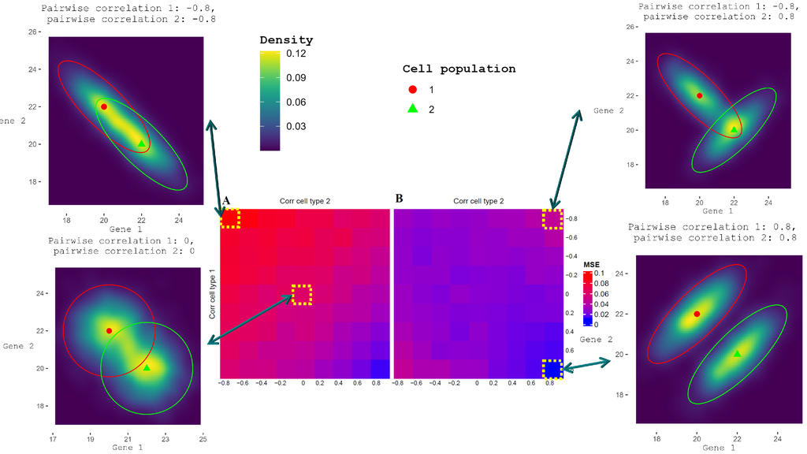

Figure 2: We used package [ComplexHeatmap](https://jokergoo.github.io/ComplexHeatmap-reference/book/) to display the mean square error (MSE) of the estimated cell ratios, comparing the output of the deconRNASEQ algorithm [5], in Panel **A**, with our newly implemented DeCovarT algorithm, in Panel **B**. The lower the MSE, the least noisy and biased the estimates. In addition, we added two-dimensional density plots of the central scenario, parametrised by a diagonal covariance matrix, and most extreme scenarios, with the highest gene pairwise correlation. The ellipsoids represent for each cell population the $95\%$ confidence region and the red spherical and green triangular shapes represent respectively the centroids of cell population 1 and cell population 2.

```r
knitr::include_graphics("figs/deconvolution_Heatmap.png")
```

The package used to generate the simulations and infer ratios from virtual or real biological mixtures with the DeCovarT algorithm is implemented on personal Github account DeCovarT.

## Results on real datasets

The whole list of benchmarked packages is described, with their main parameters and a summary of the method used, in Table 3 below:

```r
readr::read_delim("./tables/deconvolution_methods.csv", delim = ";", show_col_types = F) %>%
  slice(1:14L) %>%
  select(-c("Online method")) %>%
  mutate( # `DeCovarT function`=gsub("_", "\\_", `DeCovarT function`),
    `DeCovarT function` = dplyr::if_else(`DeCovarT function` == "redcross", "redcross", paste0("\\Verb|", `DeCovarT function`, "|")),
    dplyr::across(everything(), ~ gsub(pattern = "redcross", "\\\\redcross", .x)),
    # across(.cols = where(is.character), kableExtra::linebreak, linebreaker = "\\\\n")
  ) %>%
  kbl(
    booktabs = T, caption = "Features of some gold-standard deconvolution algorithms, benchmarked in this package.
               \\textit{Family} returns the general type of each deconvolution algorithm, among these three classes:
               \\textit{supervised} algorithms, which use either a reference profile or assume a marker-based approach,
               in which genes are considered expressed only in one cell population. When avalaible, direct website link
               is indexed in \\textit{Online method}, and when implemented in our package, we give the name associated
               to the closely avalaible implemented function, in column \\textit{DeCovarT function}", escape = F,
  ) %>%
  row_spec(0, bold = T, align = "c", hline_after = T) %>%
  row_spec(1:14, hline_after = T) %>%
  kable_styling(latex_options = c("HOLD_position", "scale_down")) %>%
  column_spec(column = 1:5, latex_valign = "m", width = c("2cm", "3cm", "8cm", "3cm", "5cm")) %>%
  column_spec(column = 1, bold = T, border_right = T)
```

```r
data <- readr::read_delim("./tables/deconvolution_methods.csv", delim = ";", show_col_types = F) %>%
  slice(1:14L) %>%
  mutate(
    `DeCovarT function` = dplyr::if_else(`DeCovarT function` == "redcross", "redcross", paste0("`", `DeCovarT function`, "`")),
    dplyr::across(.cols = everything(), ~ gsub(pattern = "redcross", "./figs/red_cross.png", .x))
  )

flex_data <- data %>% flextable()
for (i in 1:nrow(data)) {
  red_index <- grep("red_cross", data[i, ] %>% unlist())
  flex_data <- flex_data %>%
    flextable::mk_par(
      i = i, j = red_index,
      value = flextable::as_paragraph(flextable::as_image(
        src = "./figs/red_cross.png",
        width = 0.5, height = 0.5, unit = "cm"
      ))
    )
}

flex_data %>%
  set_caption(
    caption = "Features of some gold-standard deconvolution algorithms, benchmarked in this package.
               *Family* returns the general type of each deconvolution algorithm, among these three classes:
               *supervised* algorithms, which use either a reference profile or assume a marker-based approach,
               in which genes are considered expressed only in one cell population. When avalaible, direct website link
               is indexed in  *Online method*, and when implemented in our package, we give the name associated
               to the closely avalaible implemented function, in column *DeCovarT function*",
    html_escape = F
  ) %>%
  theme_vanilla() %>%
  align(align = "center", part = "header") %>% # centre align header
  bold(j = "Algorithm", bold = TRUE, part = "body") %>%
  vline(j = "Algorithm", part = "body") %>%
  flextable::autofit()
```

Table 3: Features of some gold-standard deconvolution algorithms, benchmarked in this package. *Family* returns the general type of each deconvolution algorithm, among these three classes: *supervised* algorithms, which use either a reference profile or assume a marker-based approach, in which genes are considered expressed only in one cell population. When avalaible, direct website link is indexed in *Online method*, and when implemented in our package, we give the name associated to the closely avalaible implemented function, in column *DeCovarT function*

Algorithm

Family

Key feature

Authors

Online method

DeCovarT function

TIMER

reference-based

Optimization of the condition number (CN) of expression matrix to select markers then standard OLS (ordinary least squares) using function stats::lsfit

Abbas et al., 2009 / Li et al., 2020

http://web.cbio.uct.ac.za/~renaud/CRAN (R benchmark package, from CellMix)

`deconvolute_ratios_abbas`

DECONVOLUTE

reference-based

Deconvolution to inferfor cell cycle phase-specific profiles, obtained by Simulated Annealing.

Lu et al., 2003

http://bioinformatics.icmb.utexas.edu/deconvolute

NNLS

reference-based

Non-negative linear squared optimisation method, using the Lawson-Hanson algorithm (in R, package nnls::nnls())

Lawson et al., 1981

https://cran.r-project.org/web/packages/nnls/nnls.pdf

`deconvolute_ratios_nnls`

EPIC

reference-based

QP to account for the unit simplex constraint, weighted by the variance of the genes

Racle et al., 2017

https://github.com/GfellerLab/EPIC

DeconRNASeq

reference-based

Quadratic programming (QP) to account for the unit simplex constraint

Gong and Szustakowski, 2013

https://www.bioconductor.org/packages/release/bioc/html/DeconRNASeq.html (Bioconductor package)

`deconvolute_ratios_deconRNASeq`

quanTIseq

reference-based

Quadratic programming (QP) with intercept to account for residual noise

Finotello et al. 2017

https://github.com/icbi-lab/quanTIseq

ABIS

reference-based

robust linear regression (RLR)

Monaco et al., 2019

https://github.com/omnideconv/immunedeconv (R benchmark package)

`deconvolute_ratios_monaco`

FARDEEP

reference-based

robust linear regression (RLR) coupled with NNLS optimisation

Hao et al, 2018

https://github.com/favilaco/deconv_benchmark (R benchmark package, from deconv_benchmark)

CIBERSORT

reference-based

$\nu$-SVR with linear kernel. The most relevant genes are referred to as "support vector"

Newman et al., 2015

Registration as a student for a free use of the original R code

`deconvolute_ratios_CIBERSORT`

CIBERSORTx

unsupervised with priors

Natural extension of CIBERSORT + possibility to infer the purified gene expression profiles + batch correction, performed with COMBAT, to accout for distinct sequencing strategies

Newman et al., 2019

For a free use, same rule applies as CIBERSORT. However, original code is not provided, but instead, a self-containaing docker is supplied.

DSection

unsupervised with priors

Bayesian framework where a prior Dirichlet, possibly noisy, is assumed on the distribution of the cellular ratios and an univariate normal prior with parameters extracted from LS solution assuming known cell-type proportions. Unknown parameters estimated using Metropolis-Hastings sampling.

Erkkila et al., 2010

http://informatics.systemsbiology.net/DSection/

DeMix / DeMixt

unsupervised with priors

Designed to infer the tumoral proportion of a sample. Neither reference profiles nor mixing proportions are required but the tool can take advantage of it as strong priors. Extension to a three-component, with an additional unknown cell content has been supplied with natural extension DeMixt. Mixture is modelled as a convolution of indepent, univariate log-Normal distributions.

Ahn et al., 2013 / Wang et al., 2019

https://github.com/wwylab/DeMix

MCP-counter

marker-based

MCP scores: a) were computed using log2 geometric mean of set of markers; b) correlated to known RNA proportions in the mixture.

Becht et al., 2016

http://134.157.229.105:3838/webMCP/ (R shiny app)

xCell

marker-based

xCell is a recently published method based on ssGSEA.The xCell abundance scores are computed through the following steps: ssGSEA is performed independently and averaged for each of the 489 gene sets implemented in the GSVA R package then averaged over a cell type; platform-specific corrections as well as "spillover" contaminations to account for closely related cell types are then corried out. Abundance scores are returned for 64 immune cell types.

Aran et al., 2017

https://github.com/dviraran/xCell

# References

[1]

T. Erkkilä, S. Lehmusvaara, P. Ruusuvuori, T. Visakorpi, I. Shmulevich, and H. Lähdesmäki, “Probabilistic analysis of gene expression measurements from heterogeneous tissues,” *Bioinformatics*, 2010, doi: 10.1093/bioinformatics/btq406.

[2]

R. Mazumder and T. Hastie, “The Graphical Lasso: New Insights and Alternatives,” *Electronic Journal of Statistics*, Nov. 2011, doi: 10.1214/12-EJS740.

[3]

M. Prague, D. Commenges, J. Guedj, J. Drylewicz, and R. Thiébaut, “NIMROD: A program for inference via a normal approximation of the posterior in models with random effects based on ordinary differential equations,” *Computer Methods and Programs in Biomedicine*, Aug. 2013, doi: 10.1016/j.cmpb.2013.04.014.

[4]

K. H. Haskell and R. J. Hanson, “An algorithm for linear least squares problems with equality and nonnegativity constraints,” *Mathematical Programming*, Dec. 1981, doi: 10.1007/BF01584232.

[5]

T. Gong and J. D. Szustakowski, “DeconRNASeq: A statistical framework for deconvolution of heterogeneous tissue samples based on mRNA-Seq data,” *Bioinformatics (Oxford, England)*, 2013, doi: 10.1093/bioinformatics/btt090.

[6]

J. Ahn *et al.*, “DeMix: Deconvolution for mixed cancer transcriptomes using raw measured data,” *Bioinformatics (Oxford, England)*, 2013, doi: 10.1093/bioinformatics/btt301.

[7]

Z. Wang *et al.*, “Transcriptome Deconvolution of Heterogeneous Tumor Samples with Immune Infiltration,” *iScience*, 2018, doi: 10.1016/j.isci.2018.10.028.

[8]

M. Chion, “Développement de nouvelles méthodologies statistiques pour l’analyse de données de protéomique quantitative,” These en préparation, Strasbourg, 2018. Available: http://www.theses.fr/s269600

[9]

M. Taboga, “Metropolis-Hastings algorithm,” 2021. Available: https://www.statlect.com/fundamentals-of-statistics/Metropolis-Hastings-algorithm

# Appendix A: Theoretical details

## First and second-order derivation of the constrained DeCovarT log-likelihood function

To reparametrise the log-likelihood function (Eq.(4)) in order to explicitly handling the unit simplex constraint (Eq.(2)), we consider the following mapping function: $\boldsymbol{\psi}:\boldsymbol{\rho} \to \boldsymbol{p} \, | \quad \boldsymbol{\rho} \in \RR^{J-1} , \, \boldsymbol{p} \in ]0, 1[^{J}$ (Eq.(7)):

$$\begin{equation}
\begin{aligned}
\boldsymbol{p} = \boldsymbol{\psi} (\boldsymbol{\rho}) =
\begin{cases}
p_j = \frac{e^{\rho_j}}{\sum_{k < J} e^{\rho_k} \, + \, 1}, \, j < J\\
p_J = \frac{1}{\sum_{k < J} e^{\rho_j} + 1}
\end{cases} & \qquad
\boldsymbol{\rho} = \boldsymbol{\psi}^{-1} (\boldsymbol{p}) = \left(\ln{\left( \frac{p_j}{p_J}\right)} \right)_{j \in \{ 1, \ldots, J -1\}}
\end{aligned}
\tag{7}
\end{equation}$$

that is a $C^2$-diffeomorphism, since $\boldsymbol{\psi}$ is a bijection between $\boldsymbol{p}$ and $\boldsymbol{\rho}$ twice differentiable.

Its Jacobian, $\mathbf{J}_{\boldsymbol{\psi}} \in \mathcal{M}_{J \times (J-1)}$ is given by Eq.(8):

$$\begin{equation}
\mathbf{J}_{i,j} =
\frac{\partial p_i}{\partial \rho_{j}} =
\begin{cases}
\frac{e^{\rho_i}B_i}{A^2 },\quad i = j, \, i < J\\
\frac{-e^{\rho_j}e^{\rho_i}}{A^2 }, \quad i \neq j, \, i < J\\
\frac{-e^{\rho_j}}{A^2}, \quad i=J
\end{cases}
\tag{8}
\end{equation}$$

with $i$ indexing vector-valued $\boldsymbol{p}$ and $j$ indexing the first-order order partial derivatives of the mapping function, $A=\sum_{j' < J} \,e^{\rho_{j'}} \, + \, 1$ the sum over exponential (denominator of the mapping function) and $B=A - e^{\rho_{i}}$ the sum over ratios minus the exponential indexed with the currently considered index $i$.

The Hessian (which fortunately is symmetric for each component $j$, as expected according to the Schwarz’s theorem) of the vectorial mapping function $\boldsymbol{\psi (\rho)}$ is a third-order tensor of rank $(J-1)(J-1)J$, given by Eq.(9):

$$\begin{equation}
\begin{aligned}
\frac{\partial^2 p_i}{\partial k \partial j} &=
\begin{cases}
\frac{e^{\rho_i} e^{\rho_l} \left (-B_i + e^{\rho_i}\right)}{A^3},\, (i<J) \land \left((i\neq j) \oplus(i\neq k)\right) \quad (a)\\
\frac{2 e^{\rho_i} e^{\rho_j} e^{\rho_k} }{A^3}, \, (i<J) \land (i \neq j \neq k) \quad (b)\\
\frac{e^{\rho_i} e^{\rho_j} \left (-A + 2e^{\rho_j}\right)}{A^3}, \, (i<J) \land (j=k\neq i) \quad (c)\\
\frac{B_i e^{\rho_i} \left( B_i - e^{\rho_i}\right)}{A^3}, \, (i<J) \land (j = k = i) \quad (d)\\
\frac{e^{\rho_j} \left( -A + 2 e^{\rho_j}\right)}{A^3}, \, (i=J) \land (j = k) \quad (e)\\
\frac{2 e^{\rho_j} e^{\rho_k}}{A^3}, \, (i=J) \land (j \neq k) \quad (f)
\end{cases}
\end{aligned}
\tag{9}
\end{equation}$$

with $i$ indexing $\boldsymbol{p}$, $j$ and $k$ respectively indexing the first-order and second-order partial derivatives of the mapping function with respect to $\boldsymbol{\rho}$. In line $(a)$, $\oplus$ refers to the Boolean XOR operator, $\land$ to the AND operator and $l=\{j,k\} \setminus i$.

To derive the log-likelihood function in Eq.(5), we reparametrise $\boldsymbol{p}$ to $\boldsymbol{\rho}$, using a standard *chain rule formula*). Considering the original log-likelihood function, Eq.(4), and the mapping function, Eq.(7), the differential at the first order and at the second order is given by Eq.(10) and Eq.(11), respectively defined in $\RR^{J-1}$ and $\mathcal{M}_{(J-1)\times(J-1)}$:

$$\begin{equation}
\begin{bmatrix}
\frac{\partial \ell_{\boldsymbol{y} | \boldsymbol{\zeta}}}{\partial \rho_j}
\end{bmatrix}_{j < J}
= \sum_{i=1}^J \frac{\partial \ell_{\boldsymbol{y} | \boldsymbol{\zeta}}}{\partial p_i} \frac{\partial p_i}{\partial \rho_j}
\tag{10}
\end{equation}$$
$$\begin{equation}
\begin{bmatrix}
\frac{\partial \ell_{\boldsymbol{y}|\boldsymbol{\zeta}}^2 }{\partial \rho_k \rho_j}
\end{bmatrix}_{j < J, \, k < J} =
\sum_{i=1}^J \sum_{l=1}^J \left( \frac{\partial p_i }{\partial \rho_j} \frac{\partial^2 \ell_{\boldsymbol{y}|\boldsymbol{\zeta}} }{\partial p_i \partial p_l} \frac{\partial p_l }{\partial \rho_k}\right) \, + \, \sum_{i=1}^J \left( \frac{\partial \ell_{\boldsymbol{y}|\boldsymbol{\zeta}} }{\partial p_i} \frac{\partial^2 p_i }{\partial \rho_k \rho_j}\right) \quad (d)
\tag{11}
\end{equation}$$

# Appendix B: Natural extension towards a truly Bayesian framework

We review below in more details some papers that inspire our work as well as natural extensions of the already implemented framework in Fig.1.

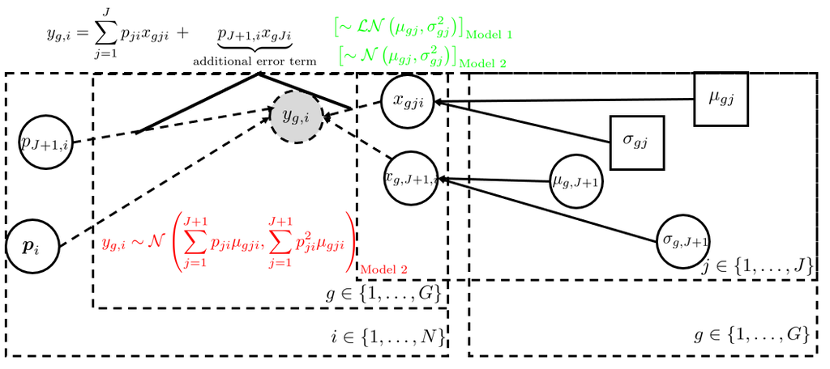

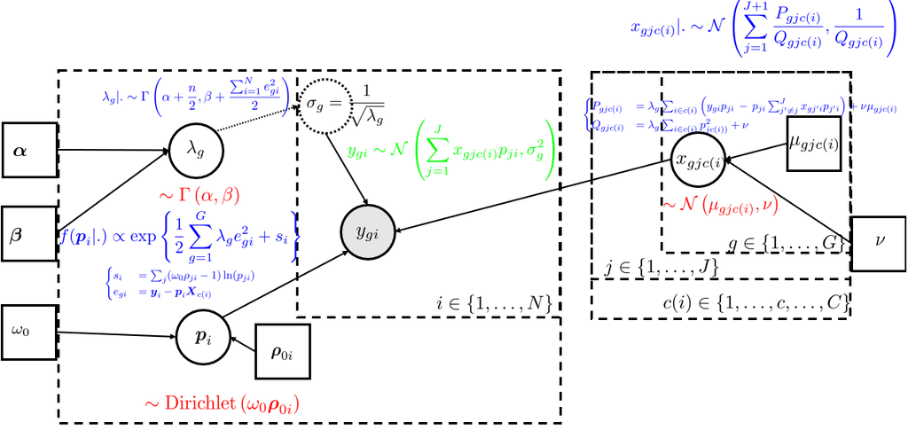

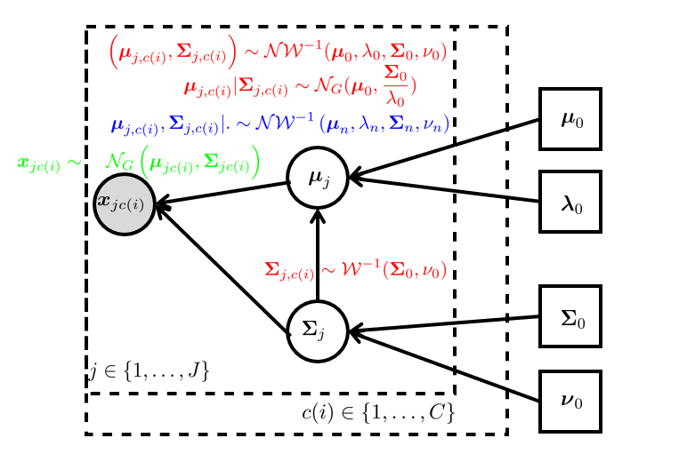

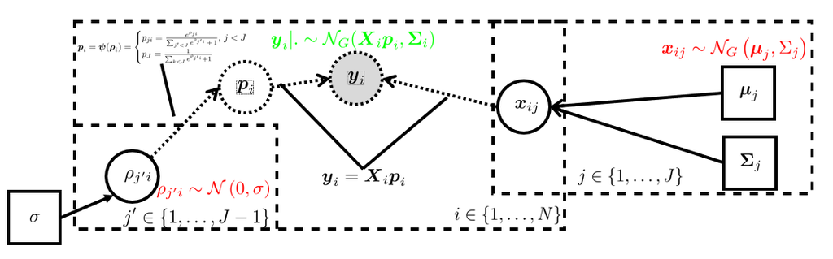

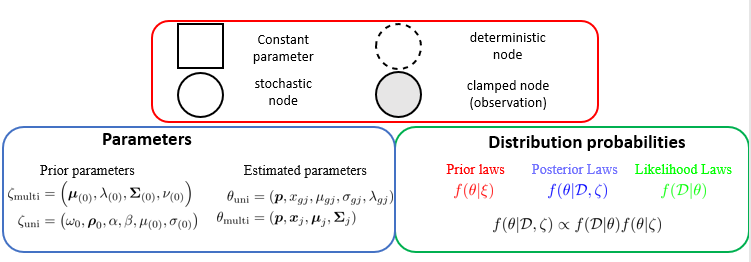

Figure 3: To compare the generative framework across several deconvolution algorithms, we homogenise indexes and parameters, and represent dependency links using the [RevBayes](https://revbayes.github.io/tutorials/intro/graph_models.html) convention. The density functions describing the distribution of the observations, conditioned on the estimated parameters, are written in green, the prior distributions of the parameters to estimate are written in red (themselves possibly conditioned on other unknown parameters, or constant, fixed-value priors), and finally, the resulting posterior distribution parameters, conditioned on both prior and likelihood functions, following the Bayes rules, are written in blue.

We characterise in further details these models below:

### Addtional details on extended DeCovarT Bayesian framework

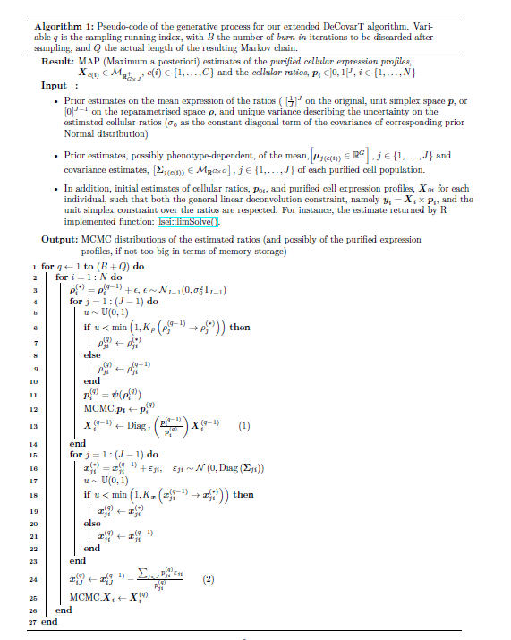

We detail in Box below the general process of the Metropolis-Hasting (MH) algorithm.

Consider the following definitions:

- Function $f(\theta | .)$ is called the *target distribution*, in our specific context, the posterior distribution of both the ratios and the individual cellular expression profiles[^10].
- The distribution $q(\theta | \theta^{(q-1)})$ is called alternatively the **proposal distribution** or the **transition kernel**, while the transient value $\theta^{(*)}$ is called the **proposal**.
- The value returned by function $K$ is called the **acceptance probability**.

Then, equipped with such functions and usual MCMC vocabulary, each iteration $(q)$ of the MH algorithm can be decomposed as the following steps:

1. Draw a proposal parameter $\theta^{(*)}$ from conditional distribution $q(\theta | \theta^{(q-1)})$.
2. Determine the probability of accepting this new value, computed as such:
   $$K (\theta) = \min \left( \frac{f(\theta^{(*)} | .)}{f(\theta^{(q-1)} | .)} \frac{q(\theta | \theta^{(q-1)})}{q( \theta^{(q-1)}| \theta )}, \, 1 \right)$$
3. Draw $u \sim \text{Unif}[0, 1]$.
4. Apply the following updating rule, as a function of a draw of the uniform distribution with success probability parameter $K (\theta)$:
   $$\theta^{(q)} =
   \begin{cases}
   \theta^{(*)}, & \, u \le K (\theta)\\
   \theta^{(q-1)}, & \, u > K (\theta)\\
   \end{cases}$$
   In the first case, we say that the proposal is *accepted*, while in the second case, it is *rejected*.

However, the specific way we design the *kernel distribution*, by updating previous parameter estimates adding them a multivariate Gaussian noise (namely $\theta^{(*)}=\theta^{(q-1)} + \epsilon$), simplifies even further the acceptance probability function. Indeed, using first,
$$\begin{aligned}
q(\theta^{(*)} | \theta^{(q-1)}) &= q (\epsilon) \\
q(\theta^{(q-1)} | \theta^{*}) &= q (-\epsilon)
\end{aligned}$$
and then deducing from the symmetric property of the multivariate Gaussian distribution that $q (\epsilon)=q (-\epsilon)$, the acceptance probability simplifies to:
$$K (\theta) = \min \left( \frac{f(\theta^{(q-1)} + \epsilon| .)}{f(\theta^{(q-1)} | .)}, \, 1 \right)$$
This specific design is referred to as [Random walk Metropolis-Hastings](https://www.statlect.com/fundamentals-of-statistics/Metropolis-Hastings-algorithm) and described in further details in [9].

We detail in Box below the general process of the Gibbs sampling algorithm, applied to the specific DeCovarT framework:

Consider the *target distribution* $f(\boldsymbol{p}, \boldsymbol{X}| \boldsymbol{\zeta}, \mathcal{D})$ , the joint density of the posterior parameters of interest, conditioned on constant, user-defined parameters $\boldsymbol{\zeta}$ and observed distribution $\mathcal{D}$, here the measured bulk estimates $\boldsymbol{Y}$. Suppose now that while we do know the joint distribution $f(\boldsymbol{p}, \boldsymbol{X}| \boldsymbol{\zeta}, \mathcal{D})$, we are however able to compute the posterior distribution, at least up to a multiplicative constant, of respectively the posterior distributions of the cellular ratios, $f(\boldsymbol{p} | \boldsymbol{X}, \boldsymbol{\zeta}, \mathcal{D})$ and the purified individual cell expression profiles, $f(\boldsymbol{X} |\boldsymbol{p} , \boldsymbol{\zeta}, \mathcal{D})$. Whenever you are able to decompose your parameters into meaningful sets, you may apply Gibbs sampling, and such distributions are referred to as *full conditional*.

In that case, the Gibbs algorithm will perform the following updated iterations:

1. Draw a proposal from $f(\boldsymbol{p}^{(q)} |\boldsymbol{X}^{(q-1)} , \boldsymbol{\zeta}, \mathcal{D})$ for the cellular ratios.
2. Use the updated cellular proportions to generate a new proposal for the purified cellular expressions: $f(\boldsymbol{X}^{(q)} |\boldsymbol{p}^{(q)} , \boldsymbol{\zeta}, \mathcal{D})$.

Generally, the idea of the Gibbs sampling is to decompose the set of parameters to sample into independent blocks, and update each of them in the same iteration, conditioned on the most updated version of the remaining parameter subsets.

Finally, when designing the proposal distribution, we must ensure it could generate any value belonging to the *support* of the target distribution, noted $R_f$, in other words, that $q(\theta^{(*)}|\theta^{(q-1)}) > 0$. This technical condition is indeed required for the validity of the *balance condition*, required for the *ergodicity* and the convergence to a stationary distribution of the MCMC sample. In addition, the deconvolution framework requires two additional linear constraints over the parameters:

   $$\begin{equation}
   \begin{aligned}
   \sum_{j<J} p_{ji}^{(q)} \boldsymbol{x}_{ji}^{(q)} + p_{Ji}^{(q)} \boldsymbol{x}_{Ji}^{(q)} &= \sum_{j<J} p_{ji}^{(q-1)} \boldsymbol{x}_{ji}^{(q-1)} + p_{Ji}^{(q-1)} \boldsymbol{x}_{Ji}^{(q-1)} = \boldsymbol{y}_i\\
   & \Longleftrightarrow \\
   \sum_{j<J} \left( \cancel{p_{ji}^{(q)}\boldsymbol{x}_{ji}^{(*)}} + p_{ji}^{(q)} \boldsymbol{\varepsilon}_{ji}^{(q)} \right)+ p_{Ji}^{(q)} \boldsymbol{x}_{Ji}^{(q)} & = \cancel{\sum_{j<J} p_{ji}^{(q-1)} \boldsymbol{x}_{ji}^{(q-1)}} + p_{Ji}^{(q-1)} \boldsymbol{x}_{Ji}^{(q-1)} \quad (1) \\
   & \Longleftrightarrow \\
   \boldsymbol{x}_{Ji}^{(q)} &= \underbrace{\frac{p_{Ji}^{(q-1)} \boldsymbol{x}_{Ji}^{(q-1)}}{p_{Ji}^{(q)}}}_{\boldsymbol{x}_{Ji}^{(*)}} - \frac{\sum_{j<J} p_{ji}^{(q)} \boldsymbol{\varepsilon}_{ji}^{(q-1)}}{p_{Ji}^{(q)}}
   \end{aligned}
   \tag{12}
   \end{equation}$$

Ou alors, sans passer par un update temporaire des profils cellulaires, et en partant directement des valeurs de $\boldsymbol{x}_{Ji}^{(q-1)}$ stockées dans la chaine MCMC??, puisque l’étape A de l’ago consiste juste à mettre à jour les ratios cellulaires, et que modifier les expressions purifiées ne changent pas temporaiement la valeur des ratios!! Si tu n’es pas d’accord, que doit-on faire avec ces “valeurs temporaires” de $\boldsymbol{X}_{Ji}^{'}$, les stocker dans la chaine MCMC, mais dans ce cas, on aurait deux fois plus d’échantillons indépendants que pour les ratios cellulaires?
$$\boldsymbol{x}_{Ji}^{(q)} = \boldsymbol{x}_{Ji}^{'} + \frac{\sum_{j<J} x_{ji}^{(q-1)} \left(p_{ji}^{(q-1)} - p_{ji}^{(q)}\right) - p_{ji}^{(q)} \boldsymbol{\varepsilon}_{ji}^{(q)}}{p_{Ji}^{(q)}}$$
“Si on est d’accord sur les équations précédentes, ne resterait plus qu’à déterminer les lois a posteriori de $\rho$ et $\boldsymbol{X}$, à la constante de normalisation près”??

[^1]: Laboratoire de Probabilités, Statistiques et Modélisation (LPSM), UMR CNRS 8001, bastien_chassagnol@laposte.net, 0000-0002-8955-2391
[^2]: Laboratoire de Probabilités, Statistiques et Modélisation (LPSM), UMR CNRS 8001, Gregory.Nuel@math.cnrs.fr, 0000-0001-9910-2354
[^3]: Les Laboratoires Servier(IRIS), etienne.becht@servier.com, 0000-0003-1859-9202
[^4]: The numerical consistency of these derivatives was asserted with the [numDeriv::genD](https://rdrr.io/pkg/numDeriv/man/genD.html) package, using the more stable Richardson’s extrapolation
[^5]: Note that Window users can not unfortunately perform parallel computation with a R interface, slowing considerably the operations compared to a Linux user. Additionally, with that function, we assume that the reference profile used is the same for all individuals.
[^6]: For the moment, you may use any `rownames` argument, however, in a near future, we plan to add automated control whether they are known and valid HGNC symbols
[^7]: It is not a Bayesian framework, but so close to my original representation, that I feel the need to quote it here.
[^8]: Alternatively, other probabilistic configurations directly parametrise the variance itself, by applying to it the so-called inverse Gamma distribution
[^9]: Its main advantage is that the sampled space explored respects the unit-simplex constraint (Eq.(2)), and integrating strong prior hypothetical knowledge, such as equi-balanced cell proportions, is rather straightforward. Indeed, cellular ratios that had been estimated using standard FACS methods prior to the deconvolution, can be directly plugged in the model, as vector $\boldsymbol{\rho}_{0i}$, while uncertainty on the quality of the estimate, can be directly described by unique multiplicative weight $\omega_{0i}$.
[^10]: Actually, since the acceptance probability function is the ratio of two density functions, any multiplicative constant, that reveals often intractable to compute, cancel out